# p8105_hw1_sx2337

Shun Xie

2022-09-15

# Problem 1

In the first step, I install and load the penguins dataset.

```r
#install.packages("palmerpenguins")
data("penguins", package = "palmerpenguins")
```

Now I can call the dataset and see size as well as the summary of the dataset using summary():

```r
print(ncol(penguins)) #print number of columns
```

```
## [1] 8
```

```r
print(nrow(penguins)) #print number of rows
```

```
## [1] 344
```

```r
summary(penguins)
```

```
##       species          island    bill_length_mm  bill_depth_mm
##  Adelie   :152   Biscoe   :168   Min.   :32.10   Min.   :13.10
##  Chinstrap: 68   Dream    :124   1st Qu.:39.23   1st Qu.:15.60
##  Gentoo   :124   Torgersen: 52   Median :44.45   Median :17.30
##                                  Mean   :43.92   Mean   :17.15
##                                  3rd Qu.:48.50   3rd Qu.:18.70
##                                  Max.   :59.60   Max.   :21.50
##                                  NA's   :2       NA's   :2
##  flipper_length_mm  body_mass_g       sex           year
##  Min.   :172.0     Min.   :2700   female:165   Min.   :2007
##  1st Qu.:190.0     1st Qu.:3550   male  :168   1st Qu.:2007
##  Median :197.0     Median :4050   NA's  : 11   Median :2008
##  Mean   :200.9     Mean   :4202                Mean   :2008
##  3rd Qu.:213.0     3rd Qu.:4750                3rd Qu.:2009
##  Max.   :231.0     Max.   :6300                Max.   :2009
##  NA's   :2         NA's   :2
```

There are `8` number of variables in the dataset, namely species, island, bill_length measuring in mm, bill_depth measuring in mm, flipper_length measuring in mm, body_mass measuring in g, sex and year. The data is recorded from year 2007 to year 2009. The size of the data is `8` columns and `344` rows. So there are a total of `344` individuals included in the dataset.

In the summary, can see that there are three types of species of penguins, namely Adelie, Chinstrap and Gentoo, living on the three islands: Biscoe, Dream and Torgersen. Bill length, bill depth, flipper length and body mass are all continuous variables. The mean of bill length is 43.92mm, with a maximum value of 59.60mm and a minimum value of 32.10mm. Bill width, on the other hand, has a range from 13.10mm to 21.50mm. The mean value for the width is 17.15mm. The flipper length has a mean of 200.9mm, ranging from 172.0mm to 231.0mm whereas the body mass of a panguins in the sample are all in the range of 2700g and 6300g, with a mean of 4202g. Note that each continuous variables contains 2 missing values in the penguins dataset.

Here is a scatter plot for flipper length in mm as dependent variable against bill length mm as independent variable (save as penguins_scatter_plot.pdf):

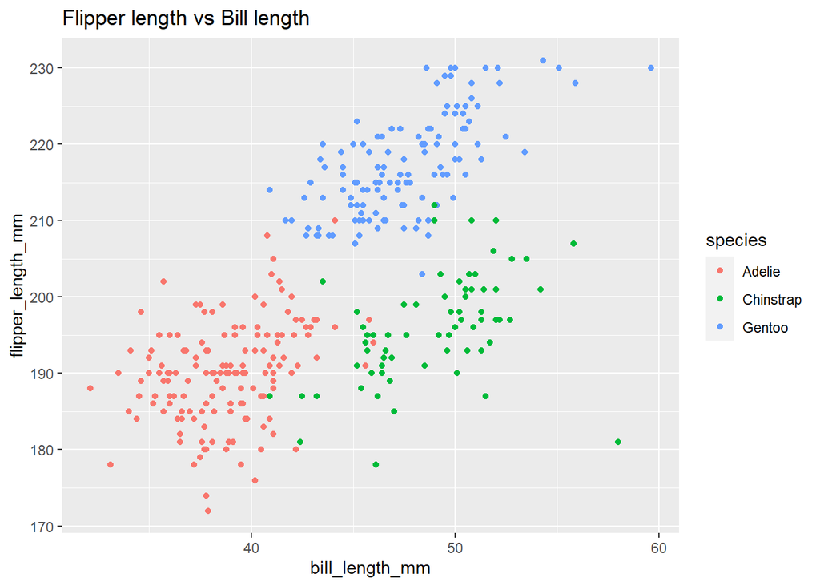

```r
ggplot(penguins, aes(x=bill_length_mm,y=flipper_length_mm, color = species))+geom_point()+
ggtitle("Flipper length vs Bill length")
```

```r
ggsave("penguins_scatter_plot.pdf", height = 4, width = 6)
```

# Section 2

In this section, I will first create a dataframe as required.

```r
problem2df <- tibble(
  random_normal = rnorm(10),
  logic_vec = random_normal>0,
  character_vec = c('a','b','c','d','e','f','g','h','i','j'),
  factor_vec = factor(c("high", "medium", "low", "low", "high", "low", "medium","medium", "low","high"))
  )
```

Try to use mean function to get the mean of all dataframe.

```r
mean(problem2df)
```

```
## [1] NA
```

The result turns out to be NA, as there are different datatypes in the dataframe such as character, numeric value, bool values and factors. Therefore, I compute the means for each column using pull function.

```r
first_col <- pull(problem2df,random_normal)
print(mean(first_col))
```

```
## [1] -0.0374061
```

```r
second_col <-pull(problem2df,logic_vec)
print(mean(second_col))
```

```
## [1] 0.6
```

```r
third_col <-pull(problem2df,character_vec)
print(mean(third_col))
```

```
## [1] NA
```

```r
fourth_col <-pull(problem2df,factor_vec)
print(mean(fourth_col))
```

```
## [1] NA
```

Now by computing each columns, only the datatype with logic value and numeric value gives a mean value. Vectors with factors and characters cannot return a value mean value. In logic value, R will interpret TRUE as 1 and FALSE as 0. But it cannot interpret datatypes other than numerical value and logic value.

Here is the result when I use as.numeric function to turn other datatypes into numeric results.

```r
num_second_col <- as.numeric(second_col)
print(num_second_col)
print(mean(num_second_col))

num_third_col <- as.numeric(third_col)
print(num_third_col)
print(mean(num_third_col))

num_fourth_col <- as.numeric(fourth_col)
print(num_fourth_col)
print(mean(num_fourth_col))
```

As required, the result is hided. But it turns out that R is able to turn bool type and factors into numeric values using as.numeric. Now factors are values 1,2,3 depends on the level of the factor. Also TRUE will become 1 and FALSE will become 0 after using as.numeric. Therefore, both factor and bool type will give a mean in numerical result whereas characters cannot.

This explains what happened when I take the mean. Logic value and numeric value can be interpreted as numbers as discussed before whereas characters cannot. Factors are able to become numeric value based on their level using as.numeric function but it cannot be directly interpreted as a numeric value. Thus, it cannot return mean value without transferring to a numeric value.